# Checking GPS Data

Hannah Moshontz and Kendra Wyant

2020-10-29

### Notes

This script checks data from RISK participants’ gps observations by computing descriptives and checking for missingness and potential errors.

### Setup

Paths

```r
path_data <- "./analysis/shared/data"
```

Packages

```r
library(tidyverse)
library(janitor)
library(psych)
library(lubridate)
library(kableExtra)
library(readxl)
library(data.table)
library(ggplot2)
```

### Import Data and glimpse()

GPS data

```r
gps <- read_rds(file.path(path_data, "ds_gps.rds")) %>%
  as.data.table() %>% #using data.table because this is a large file and dt is faster with big files
  glimpse()
```

```
## Rows: 1,164,169
## Columns: 17
## $ subid            <chr> "001", "001", "001", "001", "001", "001", "001", "...
## $ time_central     <dttm> 2017-03-02 08:32:38, 2017-03-02 08:36:38, 2017-03...
## $ lat              <dbl> 43.09339, 43.09339, 43.09339, 43.09269, 43.09238, ...
## $ long             <dbl> -89.29027, -89.29027, -89.29027, -89.29156, -89.29...
## $ next_time        <drtn> 4.0000000 mins, 0.0000000 mins, 0.3833333 mins, 0...
## $ next_dist        <dbl> 0.00000, 0.00000, 130.42299, 84.68458, 200.80229, ...
## $ previous_dist    <dbl> NA, 0.00000, 0.00000, 130.42299, 84.68458, 200.802...
## $ known_place_id   <dbl> 3, 3, 3, NA, NA, NA, NA, NA, NA, NA, NA, NA, NA, N...
## $ known_place_type <chr> "HOME", "HOME", "HOME", NA, NA, NA, NA, NA, NA, NA...
## $ drank            <chr> "YES", "YES", "YES", NA, NA, NA, NA, NA, NA, NA, N...
## $ emotion          <chr> "MIXED", "MIXED", "MIXED", NA, NA, NA, NA, NA, NA,...
## $ risk             <chr> "LOW", "LOW", "LOW", NA, NA, NA, NA, NA, NA, NA, N...
## $ avoid            <chr> "NO", "NO", "NO", NA, NA, NA, NA, NA, NA, NA, NA, ...
## $ alcohol          <chr> "YES", "YES", "YES", NA, NA, NA, NA, NA, NA, NA, N...
## $ known_vacation   <chr> NA, NA, NA, NA, NA, NA, NA, NA, NA, NA, NA, NA, NA...
## $ app_source       <fct> moves, moves, moves, moves, moves, moves, moves, m...
## $ data_type        <chr> "gps", "gps", "gps", "gps", "gps", "gps", "gps", "...
```

```r
gps <- gps %>%
  mutate(date_central = date(time_central),
         hour_central = hour(time_central),
         subid = as.double(subid))
```

Staff notes

```r
gps_notes <- read_xlsx(file.path("./analysis/notes/gps_review_notes.xlsx")) %>%
  clean_names("snake") %>%
    glimpse()
```

```
## Rows: 118
## Columns: 10
## $ sub_id                <dbl> 162, 51, 74, 97, 42, 30, 137, 39, 134, 84, 65...
## $ n                     <dbl> 141, 261, 333, 769, 837, 931, 899, 1215, 1147...
## $ first_day             <dttm> 2018-11-19 15:51:01, 2018-03-16 10:38:04, 20...
## $ last_day              <dttm> 2019-02-16 14:30:39, 2018-05-31 18:54:34, 20...
## $ days                  <dbl> 88.94419, 76.34479, 91.28169, 91.27443, 90.72...
## $ ppd                   <dbl> 1.585264, 3.418701, 3.648048, 8.425141, 9.225...
## $ phone_type            <chr> "Samsung", "Samsung", "Alcatel", "Samsung", "...
## $ used_moves_follow_mee <chr> "FollowMee", "MOVES", "Both", "FollowMee", "M...
## $ rarely_left_home      <chr> "Rarely Left Home", NA, "Rarely Left Home", N...
## $ notes                 <chr> NA, NA, "Worked close to home", "Worked close...
```

Visit dates

```r
visits <- read_rds(file.path(path_data, "ds_visits.rds")) %>%
  mutate(n_study_days = as.numeric( #calculate days on study
    difftime(end_study, start_study, units = "days")) + 1) %>%
  glimpse()
```

```
## Rows: 154
## Columns: 9
## $ subid        <dbl> 1, 2, 3, 5, 6, 7, 9, 10, 11, 15, 16, 18, 19, 20, 21, 2...
## $ screen       <date> 2017-02-01, 2017-02-17, 2017-03-07, 2017-05-31, 2017-...
## $ intake       <date> 2017-03-01, 2017-03-23, 2017-03-21, 2017-06-19, 2017-...
## $ start_study  <date> 2017-03-02, 2017-03-24, 2017-03-22, 2017-06-20, 2017-...
## $ followup1    <date> 2017-03-31, 2017-04-21, 2017-04-26, 2017-07-19, 2017-...
## $ followup2    <date> 2017-05-01, 2017-05-22, 2017-05-24, 2017-08-21, 2017-...
## $ end_study    <date> 2017-05-31, 2017-06-16, 2017-06-20, 2017-09-18, 2017-...
## $ final_visit  <date> 2017-06-05, 2017-06-16, 2017-06-21, 2017-09-22, 2017-...
## $ n_study_days <dbl> 91, 85, 91, 91, 91, 92, 91, 91, 91, 91, 76, 91, 91, 91...
```

Location reports

```r
locations <- read_rds(file.path(path_data, "ds_locations_report.rds")) %>%
  select(subid, city, state, type, drank, alcohol, emotion, risk, avoid, vacation,
         long, lat, utc) %>%
  mutate(type = tolower(type),
         drank = tolower(drank),
         alcohol = tolower(alcohol),
         emotion = tolower(emotion),
         risk = tolower(risk),
         avoid = tolower(avoid),
         vacation = tolower(vacation)) %>%
  mutate(state = case_when(state == "Wi" ~ "WI",
                           TRUE ~ state)) %>% #FIX in processing and then remove
  glimpse()
```

```
## Rows: 5,231
## Columns: 13
## $ subid    <dbl> 1, 1, 1, 1, 1, 1, 1, 1, 1, 1, 1, 1, 1, 1, 1, 1, 1, 1, 1, 1...
## $ city     <chr> "Madison", "Madison", "Madison", "Madison", "Madison", "Ma...
## $ state    <chr> "WI", "WI", "WI", "WI", "WI", "WI", "WI", "WI", "WI", "WI"...
## $ type     <chr> "home of family member", "liquor store", "home", "liquor s...
## $ drank    <chr> "yes", "no", "yes", "no", "no", "no", "no", "no", "no", "n...
## $ alcohol  <chr> "yes", "yes", "yes", "yes", "yes", "no", "no", "no", "no",...
## $ emotion  <chr> "mixed", "mixed", "mixed", "mixed", "mixed", "pleasant", "...
## $ risk     <chr> "low", "high", "low", "high", "high", "no", "no", "no", "n...
## $ avoid    <chr> "no", "yes", "no", "yes", "yes", "no", "no", "no", "no", "...
## $ vacation <chr> NA, NA, NA, NA, NA, NA, NA, NA, NA, NA, NA, NA, NA, NA, NA...
## $ long     <dbl> -89.29272, -89.30367, -89.29017, -89.32479, -89.31896, -89...
## $ lat      <dbl> 43.09011, 43.08377, 43.09328, 43.08460, 43.09681, 43.11457...
## $ utc      <dbl> 1487871000, 1487871000, 1487871000, 1487871000, 1487871000...
```

```r
## ERROR NOTE -- there's a typo. Subject 242's place of work is listed as being in the state of "Wi" rather than "WI"
```

There are 154 subjects contributing 1164169 gps observations.

The earliest recorded observation is from 2017-03-02 and the last is from 2019-12-04.

### Descriptives

#### Continuous variables

```r
gps %>%
  select(next_time, next_dist, hour_central) %>%
  mutate(next_time = as.numeric(next_time)) %>%
  describe(na.rm = TRUE)
```

```
##              vars       n   mean       sd median trimmed    mad min        max
## next_time       1 1164015  16.23    89.89   1.28    1.94   1.38   0    2870.92
## next_dist       2 1162501 707.89 10481.84 139.24  308.38 206.24   0 2922442.66
## hour_central    3 1164169  13.45     4.97  14.00   13.60   5.93   0      23.00
##                   range   skew kurtosis   se
## next_time       2870.92  11.98   180.38 0.08
## next_dist    2922442.66 170.89 36821.24 9.72
## hour_central      23.00  -0.32    -0.22 0.00
```

Next time is extremely skewed, as in next distance, suggesting that there are some major gaps in gps.

#### Data type

```r
gps %>%
  tabyl(data_type, show_na = TRUE) %>%
  adorn_totals("row") %>%
  kable() %>%
  kable_styling(full_width = FALSE, position = "left", bootstrap_options = "condensed")
```

| data_type | n | percent | valid_percent |
| --- | --- | --- | --- |
| gps | 1161978 | 0.9981180 | 0.999202 |
| network | 928 | 0.0007971 | 0.000798 |
| NA | 1263 | 0.0010849 | NA |
| Total | 1164169 | 1.0000000 | 1.000000 |

```r
gps %>%
  tabyl(data_type, app_source, show_na = TRUE) %>%
  adorn_totals("row") %>%
  kable() %>%
  kable_styling(full_width = FALSE, position = "left", bootstrap_options = "condensed")
```

| data_type | moves | followmee | NA_ |
| --- | --- | --- | --- |
| gps | 576059 | 585919 | 0 |
| network | 0 | 928 | 0 |
| NA | 0 | 0 | 1263 |
| Total | 576059 | 586847 | 1263 |

The vast majority of gps observations were labeled as gps as opposed to network-type observations. Only followmee produced network-type observations.

#### App source

```r
gps %>%
  tabyl(app_source, show_na = TRUE) %>%
  adorn_totals("row") %>%
  kable() %>%
  kable_styling(full_width = FALSE, position = "left", bootstrap_options = "condensed")
```

| app_source | n | percent | valid_percent |
| --- | --- | --- | --- |
| moves | 576059 | 0.4948242 | 0.4953616 |
| followmee | 586847 | 0.5040909 | 0.5046384 |
| NA | 1263 | 0.0010849 | NA |
| Total | 1164169 | 1.0000000 | 1.0000000 |

About half of observations came from each app.

#### Known place types

```r
gps %>%
  mutate(known_place_type = tolower(known_place_type)) %>%
  tabyl(known_place_type, show_na = TRUE) %>%
  adorn_totals("row") %>%
  kable() %>%
  kable_styling(full_width = FALSE, position = "left", bootstrap_options = "condensed")
```

| known_place_type | n | percent | valid_percent |
| --- | --- | --- | --- |
| aa/recovery meeting | 2801 | 0.0024060 | 0.0088108 |
| bar | 3670 | 0.0031525 | 0.0115443 |
| church | 459 | 0.0003943 | 0.0014438 |
| coffee shop/cafe | 2801 | 0.0024060 | 0.0088108 |
| errands | 30122 | 0.0258743 | 0.0947513 |
| gym/fitness center | 3650 | 0.0031353 | 0.0114814 |
| health care | 3537 | 0.0030382 | 0.0111259 |
| home | 151852 | 0.1304381 | 0.4776632 |
| home of family member | 12026 | 0.0103301 | 0.0378288 |
| home of friend | 13148 | 0.0112939 | 0.0413581 |
| liquor store | 5252 | 0.0045114 | 0.0165206 |
| other | 15638 | 0.0134328 | 0.0491906 |
| park | 1039 | 0.0008925 | 0.0032683 |
| restaurant | 12792 | 0.0109881 | 0.0402383 |
| school | 2344 | 0.0020135 | 0.0073732 |
| volunteer | 978 | 0.0008401 | 0.0030764 |
| work | 55797 | 0.0479286 | 0.1755141 |
| NA | 846263 | 0.7269245 | NA |
| Total | 1164169 | 1.0000000 | 1.0000000 |

The majority of gps observations are not associated with a known place.

#### Place qualities: drank

```r
locations %>%
  tabyl(drank, show_na = TRUE) %>%
  adorn_totals("row") %>%
  kable() %>%
  kable_styling(full_width = FALSE, position = "left", bootstrap_options = "condensed")
```

| drank | n | percent | valid_percent |
| --- | --- | --- | --- |
| no | 3926 | 0.7505257 | 0.7506692 |
| yes | 1304 | 0.2492831 | 0.2493308 |
| NA | 1 | 0.0001912 | NA |
| Total | 5231 | 1.0000000 | 1.0000000 |

Most known places were places where participants had not drank previously.

```r
gps %>%
  mutate(drank = tolower(drank)) %>%
  tabyl(drank, show_na = TRUE) %>%
  adorn_totals("row") %>%
  kable() %>%
  kable_styling(full_width = FALSE, position = "left", bootstrap_options = "condensed")
```

| drank | n | percent | valid_percent |
| --- | --- | --- | --- |
| no | 154622 | 0.1328175 | 0.4863902 |
| yes | 163275 | 0.1402503 | 0.5136098 |
| NA | 846272 | 0.7269323 | NA |
| Total | 1164169 | 1.0000000 | 1.0000000 |

Gps observations at known places were a roughly equal mix of visits to places where participants had drank and those they had not.

#### Place qualities: alcohol

```r
locations %>%
  tabyl(alcohol, show_na = TRUE) %>%
  adorn_totals("row") %>%
  kable() %>%
  kable_styling(full_width = FALSE, position = "left", bootstrap_options = "condensed")
```

| alcohol | n | percent | valid_percent |
| --- | --- | --- | --- |
| no | 2839 | 0.5427261 | 0.5428298 |
| yes | 2391 | 0.4570828 | 0.4571702 |
| NA | 1 | 0.0001912 | NA |
| Total | 5231 | 1.0000000 | 1.0000000 |

Of known places, the slight majority were places where alcohol was not available.

```r
gps %>%
  mutate(alcohol = tolower(alcohol)) %>%
  tabyl(alcohol, show_na = TRUE) %>%
  adorn_totals("row") %>%
  kable() %>%
  kable_styling(full_width = FALSE, position = "left", bootstrap_options = "condensed")
```

| alcohol | n | percent | valid_percent |
| --- | --- | --- | --- |
| no | 172408 | 0.1480953 | 0.5423392 |
| yes | 145489 | 0.1249724 | 0.4576608 |
| NA | 846272 | 0.7269323 | NA |
| Total | 1164169 | 1.0000000 | 1.0000000 |

Of gps observations at known places, a slight majority were at places where alcohol was not available compared places where alcohol was available.

#### Place qualities: risk

```r
locations %>%
  tabyl(risk, show_na = TRUE) %>%
  adorn_totals("row") %>%
  kable() %>%
  kable_styling(full_width = FALSE, position = "left", bootstrap_options = "condensed")
```

| risk | n | percent | valid_percent |
| --- | --- | --- | --- |
| high | 559 | 0.1068629 | 0.1069243 |
| low | 685 | 0.1309501 | 0.1310252 |
| medium | 498 | 0.0952017 | 0.0952563 |
| no | 3486 | 0.6664118 | 0.6667942 |
| NA | 3 | 0.0005735 | NA |
| Total | 5231 | 1.0000000 | 1.0000000 |

Most known places posed no risk to participants’ sobriety.

```r
gps %>%
  mutate(risk = tolower(risk)) %>%
  tabyl(risk, show_na = TRUE) %>%
  adorn_totals("row") %>%
  kable() %>%
  kable_styling(full_width = FALSE, position = "left", bootstrap_options = "condensed")
```

| risk | n | percent | valid_percent |
| --- | --- | --- | --- |
| high | 34526 | 0.0296572 | 0.1088070 |
| low | 72870 | 0.0625940 | 0.2296463 |
| medium | 53589 | 0.0460320 | 0.1688832 |
| no | 156329 | 0.1342838 | 0.4926634 |
| NA | 846855 | 0.7274330 | NA |
| Total | 1164169 | 1.0000000 | 1.0000000 |

Gps observations at known places were often at places that posed no or low risk to their sobriety.

#### Place qualities: avoid

```r
locations %>%
  tabyl(avoid, show_na = TRUE) %>%
  adorn_totals("row") %>%
  kable() %>%
  kable_styling(full_width = FALSE, position = "left", bootstrap_options = "condensed")
```

| avoid | n | percent |
| --- | --- | --- |
| no | 5000 | 0.9558402 |
| yes | 231 | 0.0441598 |
| Total | 5231 | 1.0000000 |

Most known places were places participants were not avoiding.

```r
gps %>%
  mutate(avoid = tolower(avoid)) %>%
  tabyl(avoid, show_na = TRUE) %>%
  adorn_totals("row") %>%
  kable() %>%
  kable_styling(full_width = FALSE, position = "left", bootstrap_options = "condensed")
```

| avoid | n | percent | valid_percent |
| --- | --- | --- | --- |
| no | 311387 | 0.2674758 | 0.9794785 |
| yes | 6524 | 0.0056040 | 0.0205215 |
| NA | 846258 | 0.7269202 | NA |
| Total | 1164169 | 1.0000000 | 1.0000000 |

People rarely went to places that they were avoiding.

#### Place qualities: emotion

```r
locations %>%
  tabyl(emotion, show_na = TRUE) %>%
  adorn_totals("row") %>%
  kable() %>%
  kable_styling(full_width = FALSE, position = "left", bootstrap_options = "condensed")
```

| emotion | n | percent | valid_percent |
| --- | --- | --- | --- |
| mixed | 673 | 0.1286561 | 0.1287299 |
| neutral | 802 | 0.1533168 | 0.1534047 |
| pleasant | 3597 | 0.6876314 | 0.6880260 |
| unpleasant | 156 | 0.0298222 | 0.0298393 |
| NA | 3 | 0.0005735 | NA |
| Total | 5231 | 1.0000000 | 1.0000000 |

Most known places were rated as pleasant.

```r
gps %>%
  mutate(emotion = tolower(emotion)) %>%
  tabyl(emotion, show_na = TRUE) %>%
  adorn_totals("row") %>%
  kable() %>%
  kable_styling(full_width = FALSE, position = "left", bootstrap_options = "condensed")
```

| emotion | n | percent | valid_percent |
| --- | --- | --- | --- |
| mixed | 81771 | 0.0702398 | 0.2572710 |
| neutral | 35132 | 0.0301777 | 0.1105336 |
| pleasant | 195884 | 0.1682608 | 0.6162975 |
| unpleasant | 5053 | 0.0043404 | 0.0158979 |
| NA | 846329 | 0.7269812 | NA |
| Total | 1164169 | 1.0000000 | 1.0000000 |

Gps observations at known places were often at places rated as pleasant (rather than neutral, mixed, or unpleasant).

#### Place qualities: vacation

```r
locations %>%
  tabyl(vacation, show_na = TRUE) %>%
  adorn_totals("row") %>%
  kable() %>%
  kable_styling(full_width = FALSE, position = "left", bootstrap_options = "condensed")
```

| vacation | n | percent | valid_percent |
| --- | --- | --- | --- |
| no | 4972 | 0.9504875 | 0.9605873 |
| yes | 204 | 0.0389983 | 0.0394127 |
| NA | 55 | 0.0105142 | NA |
| Total | 5231 | 1.0000000 | 1.0000000 |

Most known places were not associated with a vacation.

```r
gps %>%
  mutate(known_vacation = tolower(known_vacation)) %>%
  tabyl(known_vacation, show_na = TRUE) %>%
  adorn_totals("row") %>%
  kable() %>%
  kable_styling(full_width = FALSE, position = "left", bootstrap_options = "condensed")
```

| known_vacation | n | percent | valid_percent |
| --- | --- | --- | --- |
| no | 307478 | 0.2641180 | 0.9883956 |
| yes | 3610 | 0.0031009 | 0.0116044 |
| NA | 853081 | 0.7327811 | NA |
| Total | 1164169 | 1.0000000 | 1.0000000 |

Almost all gps observations were not associated with a vacation.

#### Place qualities: city and state

```r
locations %>%
  count(state, sort = TRUE) %>%
  kable(label = "State frequencies of all known places") %>%
  kable_styling(full_width = FALSE, position = "left", bootstrap_options = "condensed")
```

| state | n |
| --- | --- |
| WI | 4943 |
| IL | 60 |
| FL | 41 |
| IA | 29 |
| CO | 19 |
| MN | 19 |
| MI | 11 |
| NY | 11 |
| VA | 11 |
| TX | 10 |
| CA | 9 |
| OH | 8 |
| Mexico | 7 |
| LA | 6 |
| UT | 6 |
| KY | 5 |
| MO | 5 |
| HI | 4 |
| MA | 4 |
| NH | 3 |
| SC | 3 |
| Washington DC | 3 |
| ID | 2 |
| ND | 2 |
| NM | 2 |
| WY | 2 |
| DC | 1 |
| GA | 1 |
| IN | 1 |
| MT | 1 |
| NC | 1 |
| SD | 1 |

```r
locations %>%
  filter(vacation == "no") %>%
  count(state, sort = TRUE) %>%
  kable(label = "State frequencies of known places not associated with vacation") %>%
  kable_styling(full_width = FALSE, position = "left", bootstrap_options = "condensed")
```

| state | n |
| --- | --- |
| WI | 4861 |
| IL | 48 |
| IA | 29 |
| MN | 13 |
| OH | 5 |
| CO | 4 |
| LA | 4 |
| FL | 2 |
| MI | 2 |
| DC | 1 |
| IN | 1 |
| NY | 1 |
| SD | 1 |

Most known places are in WI. A few are outside of the continental US (Mexico and Hawaii). All known places outside of the US are associated with a vacation.

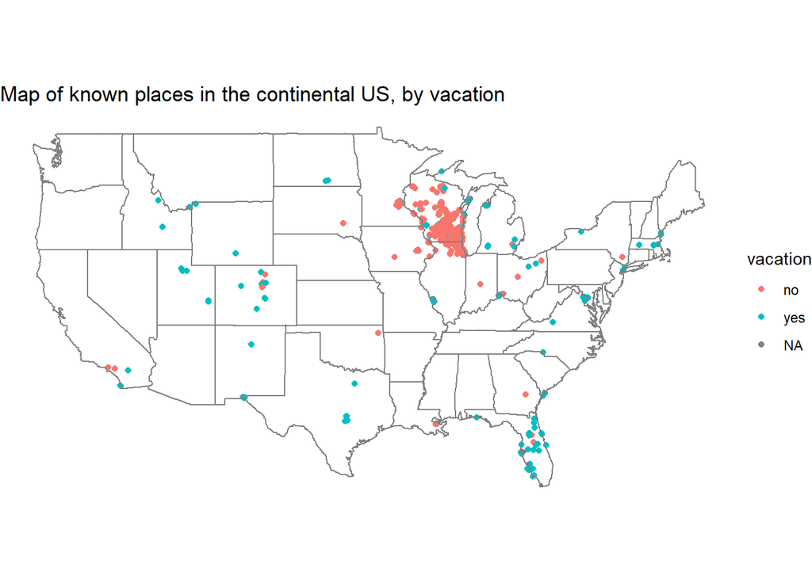

```r
#used this video to help guide my map exploration https://youtu.be/O1oDIQV6VKU
locations %>%
  filter(state != "Mexico", state != "HI") %>% #focusing just on continental US
  ggplot(aes(long, lat, color = vacation)) +
  geom_point() +
  borders("state") +
  coord_map() +
  theme_void() +
  ggtitle("Map of known places in the continental US, by vacation")
```

Map of known places helps us see some low frequency US states, and suggests that the vacation label doesn’t cover all travel (e.g., work-related travel).

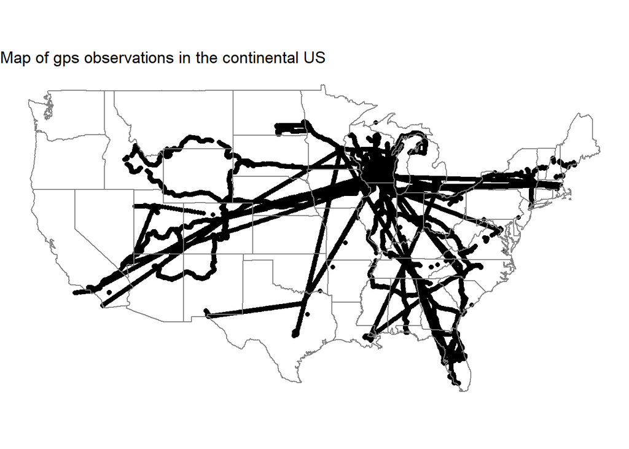

```r
gps %>%
  filter(lat >= 25, long >= -120) %>% #restricting to continental US
  ggplot(aes(long, lat)) +
  geom_point() +
  borders("state") +
  coord_map() +
  theme_void() +
  ggtitle("Map of gps observations in the continental US")
```

Map of all GPS observations is hard to make sense of because frequency is not well-represented.

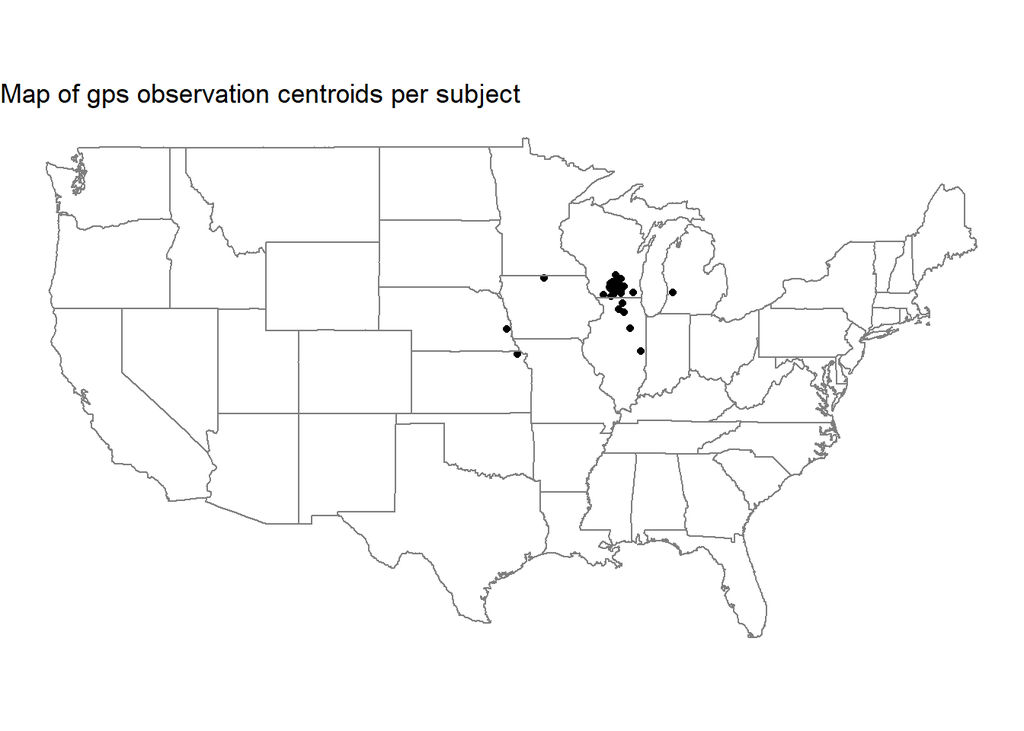

```r
gps_averaged <- gps %>% #calculating each person's centroid
  group_by(subid) %>%
  summarize(n_obs = n(),
            long_avg = mean(long),
            lat_avg = mean(lat),
            long_sd = sd(long),
            lat_sd = sd(lat))

gps_averaged %>% #mapping centroids
  ggplot(aes(long_avg, lat_avg)) +
  geom_point() +
  borders("state") +
  coord_map() +
  theme_void() +
  ggtitle("Map of gps observation centroids per subject")
```

Most people spent most of their time in the Madison, WI area.

#### Place qualities: home

```r
locations %>%
  group_by(subid) %>%
  filter(type == "home") %>%
  summarize(number_of_homes = n()) %>%
  ungroup() %>%
  tabyl(number_of_homes) %>%
  kable(label = "Frequencies of known places per subject categorized as home") %>%
  kable_styling(full_width = FALSE, position = "left", bootstrap_options = "condensed")
```

| number_of_homes | n | percent |
| --- | --- | --- |
| 1 | 134 | 0.8701299 |
| 2 | 18 | 0.1168831 |
| 3 | 2 | 0.0129870 |

Most people had one known place that they categorized as their home.

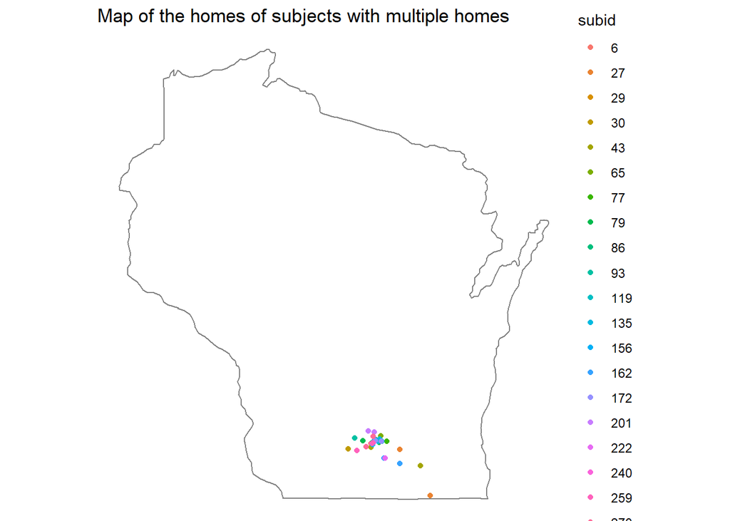

```r
subjects_with_twoplus_homes <- locations %>%
  group_by(subid) %>%
  filter(type == "home") %>%
  summarize(number_of_homes = n()) %>%
  filter(number_of_homes > 1) %>%
  pull(subid)

locations %>%
  filter(subid %in% subjects_with_twoplus_homes,
         type == "home") %>% #restricting to continental US
  mutate(subid = as.factor(subid)) %>%
  ggplot(aes(long, lat, color = subid)) +
  geom_point() +
  borders("state", "WI") +
  coord_map() +
  theme_void() +
  ggtitle("Map of the homes of subjects with multiple homes")
```

Multiple homes appear to be due to in-town moves (rather than second homes or errors).

```r
locations %>%
    filter(subid %in% subjects_with_twoplus_homes,
         type == "home") %>%
  mutate(time_central = as_datetime(utc, tz = "America/Chicago")) %>%
  group_by(subid) %>%
  mutate(previous_home_time = lag(time_central),
         homes_sep_in_time = case_when(previous_home_time < time_central ~ "yes",
                                       previous_home_time == time_central ~ "no")) %>%
  select(subid, type, long, lat, time_central, homes_sep_in_time) %>%
  filter(!is.na(homes_sep_in_time)) %>%
  tabyl(homes_sep_in_time) %>%
  kable(label = "Frequencies of whether second home reported in a session after the first home reported among subjects with multiple homes") %>%
  kable_styling(full_width = FALSE, position = "left", bootstrap_options = "condensed")
```

| homes_sep_in_time | n | percent |
| --- | --- | --- |
| no | 4 | 0.1818182 |
| yes | 18 | 0.8181818 |

Most people with multiple homes reported their second home after their first (e.g., first home was reported on intake, second home was reported at a follow-up).

```r
locations %>%
  filter(subid %in% subjects_with_twoplus_homes,
         type == "home") %>%
  mutate(report_date = date(as_datetime(utc))) %>%
  left_join(
    visits %>%
      filter(subid %in% subjects_with_twoplus_homes) %>%
      select(subid, intake, followup1, followup2, final_visit) %>%
      pivot_longer(c(intake, followup1, followup2, final_visit),
                   names_to = "visit_type",
                   values_to = "report_date"),
    by = c("subid", "report_date")) %>%
  select(subid, city, state, long, lat, report_date, visit_type)
```

### Frequency of GPS Sampling

Plots Overall

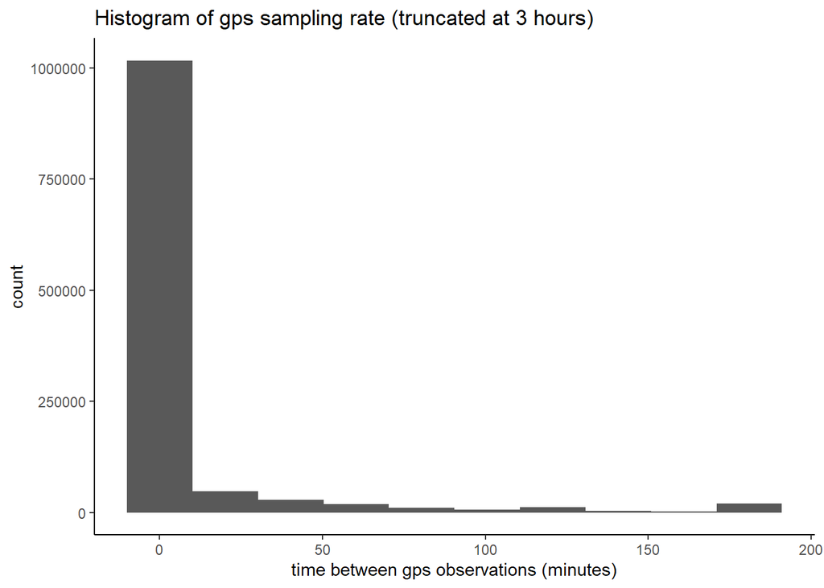

```r
gps %>%
  mutate(next_time = ifelse(
    (as.numeric(next_time) > 180),
    181, next_time)) %>%
  ggplot(aes(x = as.numeric(next_time))) +
  geom_histogram(bins = 10) +
  xlab("time between gps observations (minutes)") +
  ggtitle("Histogram of gps sampling rate (truncated at 3 hours)") +
  theme_classic()
```

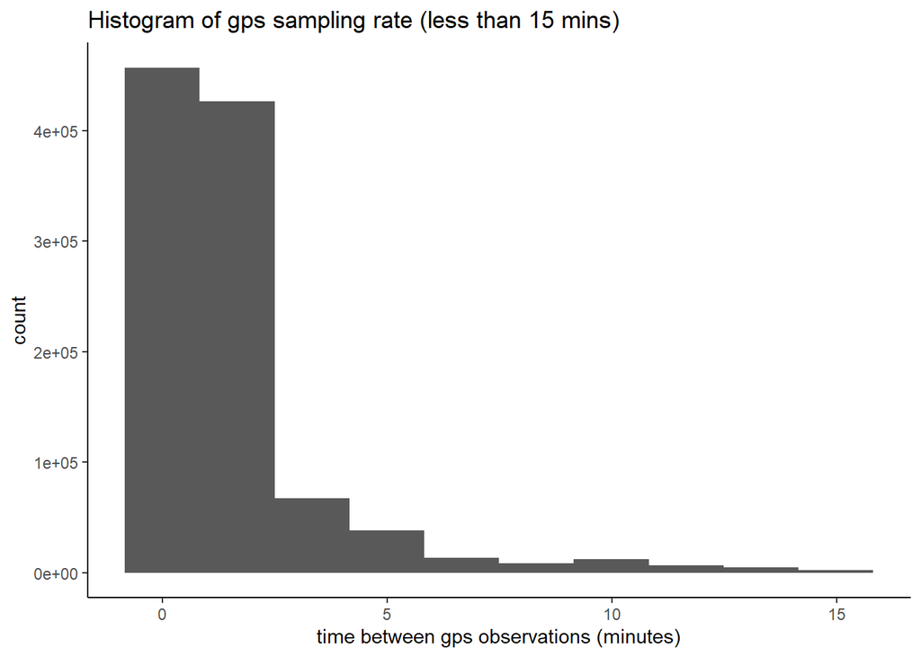

```r
gps %>%
  filter(next_time < 15) %>%
  ggplot(aes(x = as.numeric(next_time))) +
  geom_histogram(bins = 10) +
  xlab("time between gps observations (minutes)") +
  ggtitle("Histogram of gps sampling rate (less than 15 mins)") +
  theme_classic()
```

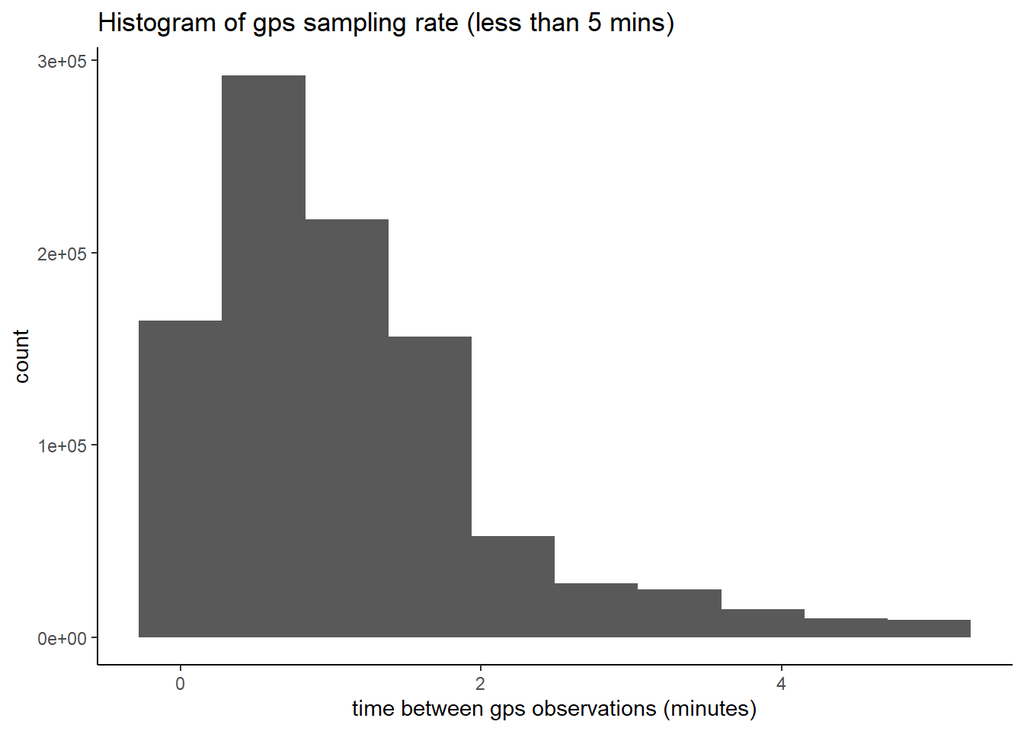

```r
gps %>%
  filter(next_time < 5) %>%
  ggplot(aes(x = as.numeric(next_time))) +
  geom_histogram(bins = 10) +
  xlab("time between gps observations (minutes)") +
  ggtitle("Histogram of gps sampling rate (less than 5 mins)") +
  theme_classic()
```

On average, gps was sampled every 16.23 minutes.z

By app

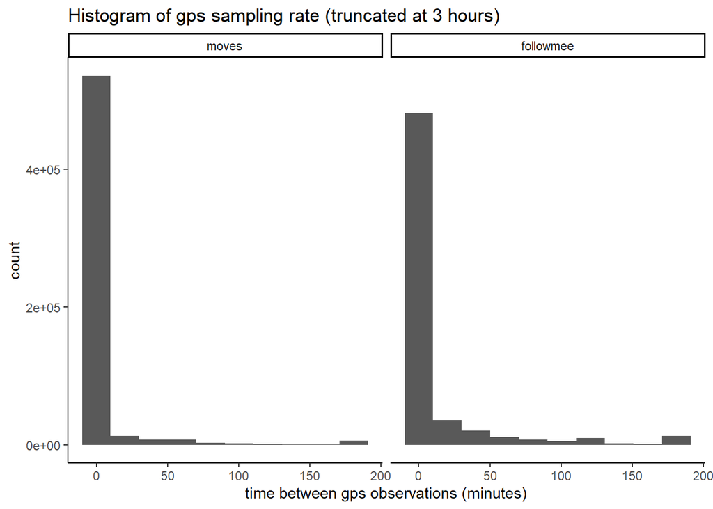

```r
gps %>%
  filter(!is.na(app_source)) %>%
  mutate(next_time = ifelse(
    (as.numeric(next_time) > 180),
    181, next_time)) %>%
  ggplot(aes(x = as.numeric(next_time))) +
  facet_grid(.~app_source) +
  geom_histogram(bins = 10) +
  xlab("time between gps observations (minutes)") +
  ggtitle("Histogram of gps sampling rate (truncated at 3 hours)") +
  theme_classic()
```

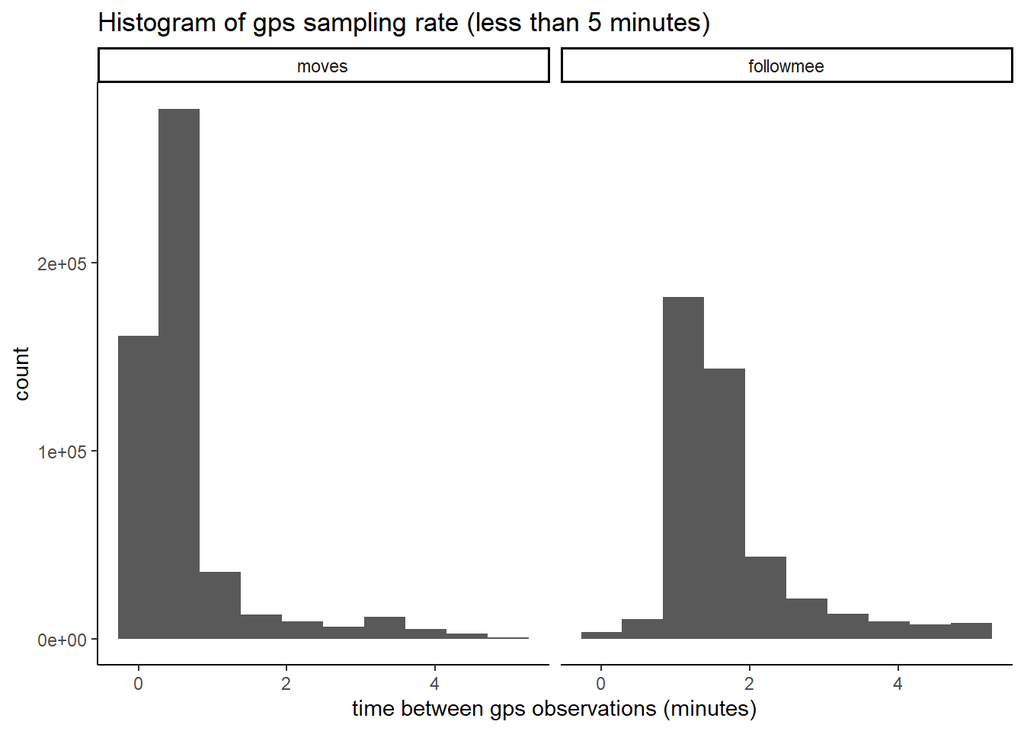

```r
gps %>%
  filter(!is.na(app_source), next_time < 5)  %>%
  ggplot(aes(x = as.numeric(next_time))) +
  facet_grid(.~app_source) +
  geom_histogram(bins = 10) +
  xlab("time between gps observations (minutes)") +
  ggtitle("Histogram of gps sampling rate (less than 5 minutes)") +
  theme_classic()
```

Sampling rates differed by app. For moves, gps was sampled every 8.93 minutes on average. For followmee, gps was sampled every 20.69 minutes on average.

### Geographic Spacing of Consecutive GPS Observations

Plots Overall

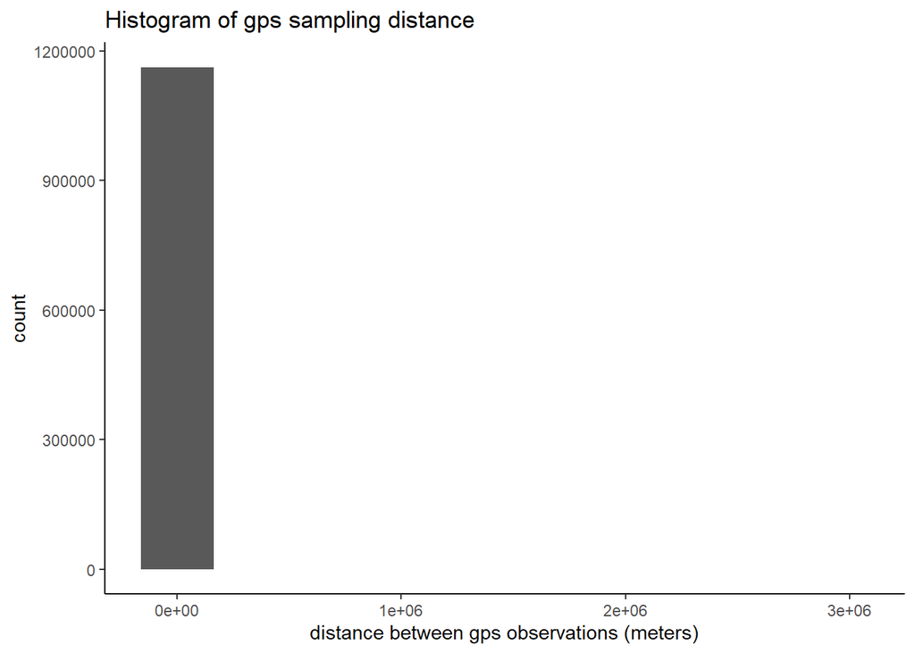

```r
gps %>%
  ggplot(aes(x = round(next_dist, 2))) +
  geom_histogram(bins = 10) +
  xlab("distance between gps observations (meters)") +
  ggtitle("Histogram of gps sampling distance") +
  theme_classic()
```

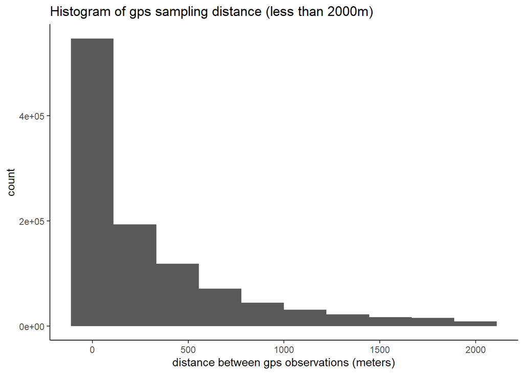

```r
gps %>%
  filter(next_dist < 2000) %>%
  ggplot(aes(x = round(next_dist, 2))) +
  geom_histogram(bins = 10) +
  xlab("distance between gps observations (meters)") +
  ggtitle("Histogram of gps sampling distance (less than 2000m)") +
  theme_classic()
```

The median gps sampling distance was 139.24 meters.

By app

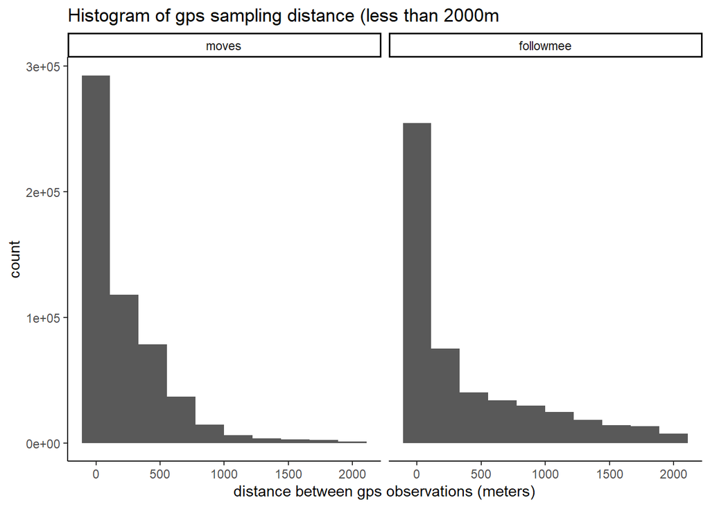

```r
gps %>%
  filter(!is.na(app_source), next_dist < 2000) %>%
  ggplot(aes(x = next_dist)) +
  facet_grid(.~app_source) +
  geom_histogram(bins = 10) +
  xlab("distance between gps observations (meters)") +
  ggtitle("Histogram of gps sampling distance (less than 2000m") +
  theme_classic()
```

Sampling distnace differed by app. For moves, median distance between gps observations was 104.07. For followmee, median distance between gps observations 191.65

### Null Island

```r
gps %>%
  filter(lat <= 1 & long <= 1, lat >= -1 & long >= -1)
```

```
## Empty data.table (0 rows and 19 cols): subid,time_central,lat,long,next_time,next_dist...
```

There are no (0,0) GPS observations.

### Number of Observations per Person

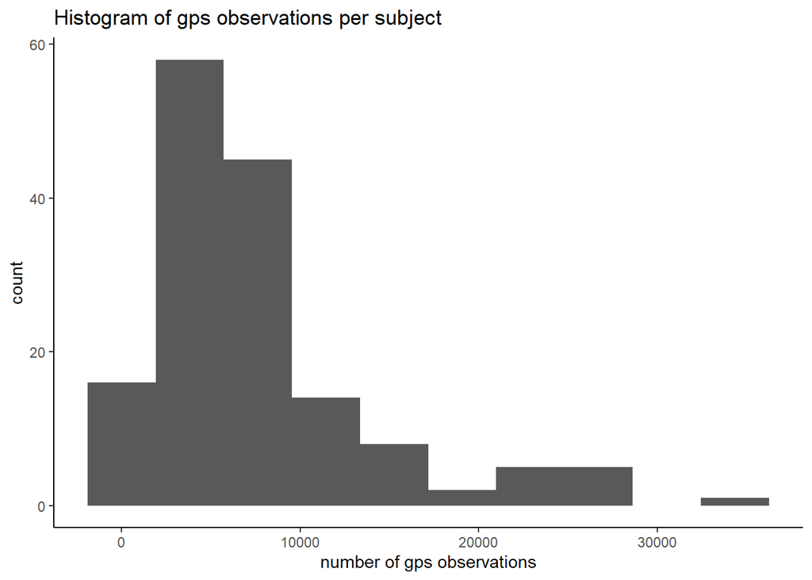

```r
gps %>%
  group_by(subid) %>%
  summarise(n_obs = n()) %>%
  ggplot(aes(x = n_obs)) +
  geom_histogram(bins = 10) +
  xlab("number of gps observations") +
  ggtitle("Histogram of gps observations per subject") +
  theme_classic()
```

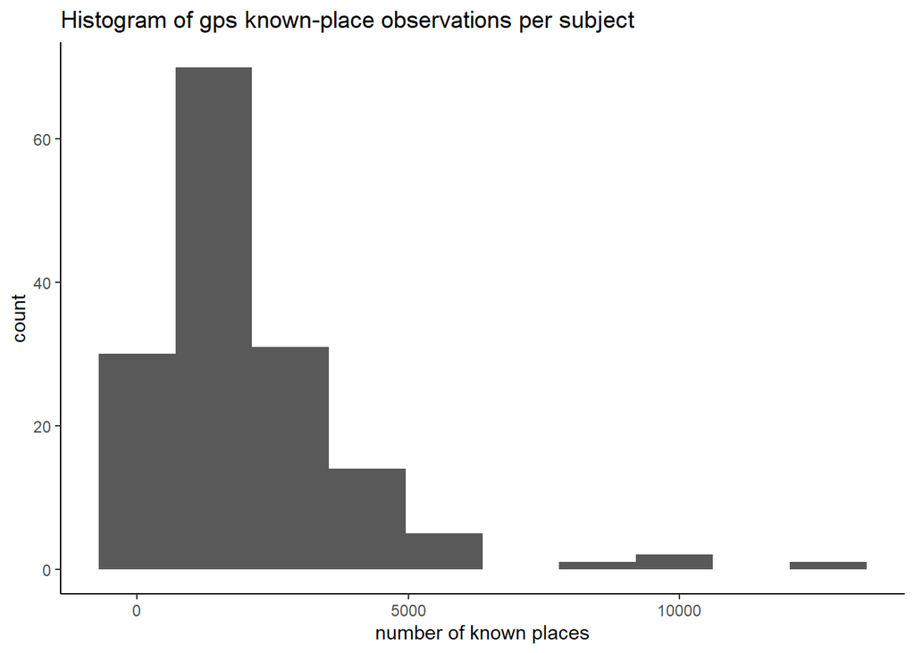

```r
gps %>%
  filter(!is.na(known_place_id)) %>%
  group_by(subid) %>%
  summarise(n_obs = n()) %>%
  ggplot(aes(x = n_obs)) +
  geom_histogram(bins = 10) +
  xlab("number of known places") +
  ggtitle("Histogram of gps known-place observations per subject") +
  theme_classic()
```

### Number of Observations per Non-Missing Day

```r
mean_avg_obs_per_day <- gps %>%
  group_by(subid, date_central) %>%
  summarise(n_obs = n()) %>%
  group_by(subid) %>%
  summarise(avg_obs_per_day = mean(n_obs)) %>%
  .$avg_obs_per_day %>%
  mean()

max_obs_per_day <- gps %>%
  group_by(subid, date_central) %>%
  summarise(n_obs = n()) %>%
  group_by(subid) %>%
  summarise(avg_obs_per_day = mean(n_obs),
            sd = sd(n_obs),
            min = min(n_obs),
            max = max(n_obs)) %>%
  .$max %>% max()
```

On average, participants provided an average of 87.76215 observations per non-missing day (max = 2581).

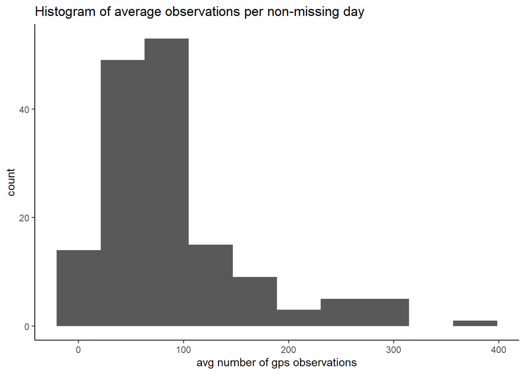

```r
gps %>%
  group_by(subid, date_central) %>%
  summarise(n_obs = n()) %>%
  group_by(subid) %>%
  summarise(avg_obs_per_day = mean(n_obs),
            min = min(n_obs),
            max = max(n_obs)) %>%
  ggplot(aes(x = avg_obs_per_day)) +
  geom_histogram(bins = 10) +
  xlab("avg number of gps observations") +
  ggtitle("Histogram of average observations per non-missing day") +
  theme_classic()
```

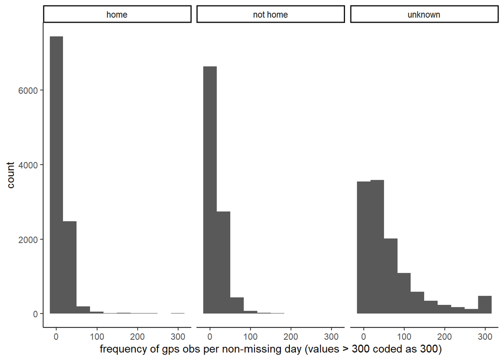

```r
gps %>%
  mutate(home_or_not =
           case_when(
             known_place_type == "HOME" ~ "home",
             known_place_type != "HOME" ~ "not home",
             is.na(known_place_type) ~ "unknown")) %>%
  group_by(subid, date_central, home_or_not) %>%
  summarize(count_per_day = n()) %>%
  mutate(count_per_day = as.double(count_per_day)) %>%
  mutate(count_per_day = case_when(count_per_day > 300 ~ 300,
                                   TRUE ~ count_per_day)) %>%
  ggplot(aes(x = count_per_day)) +
  geom_histogram(bins = 10) +
  facet_wrap(~home_or_not) +
  xlab("frequency of gps obs per non-missing day (values > 300 coded as 300)") +
  theme_classic()
```

### Missing GPS data

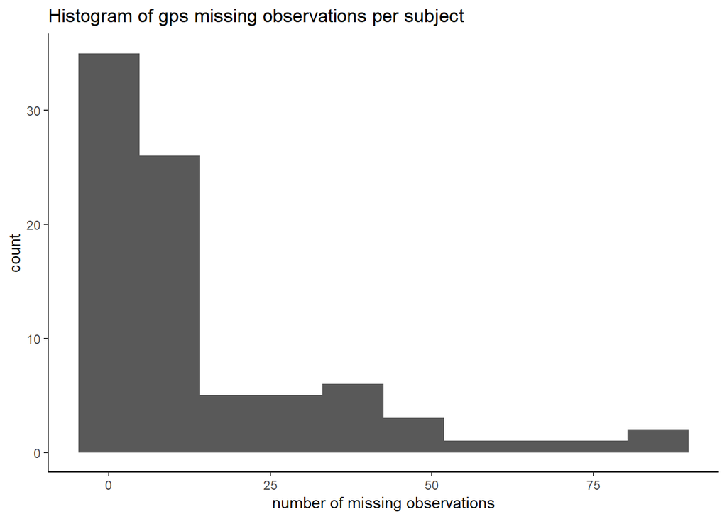

```r
gps %>%
  filter(is.na(lat)) %>%
  group_by(subid) %>%
  summarise(n_obs = n()) %>%
  ggplot(aes(x = n_obs)) +
  geom_histogram(bins = 10) +
  xlab("number of missing observations") +
  ggtitle("Histogram of gps missing observations per subject") +
  theme_classic()
```

```r
missing_gps_days <- gps %>%
  filter(is.na(lat)) %>%
  group_by(subid) %>%
  summarize(n_days_missing = n()) %>%
  arrange(desc(n_days_missing))
```

14 subjects were missing data for at least 30 on-study days.

```r
missing_gps_days %>%
  filter(n_days_missing >= 30) %>%
  kable() %>%
  kable_styling(
    bootstrap_options = "condensed",
    full_width = FALSE,
    position = "left")
```

| subid | n_days_missing |
| --- | --- |
| 190 | 86 |
| 56 | 84 |
| 2 | 80 |
| 51 | 68 |
| 80 | 56 |
| 21 | 51 |
| 74 | 43 |
| 204 | 43 |
| 84 | 42 |
| 65 | 41 |
| 117 | 40 |
| 19 | 38 |
| 167 | 37 |
| 207 | 34 |

Some of these high missing day counts might be due to errors in the visits file.

```r
gps %>%
  group_by(subid, date_central) %>%
  count() %>% # count gps obs per on-study day per subject
  filter(n > 1, n <= 5) %>% #filter to between 1 (which includes null obs, and 5)
  tabyl(subid) %>% # count number of days with 2 to 5 observations per subject
  filter(n > 10) %>% #look just at people who had more than 5 days with 2 to 5 observations
  rename(n_low_obs_days = n) %>%
  kable(label = "Frequencies of days with at least one gps observation but no more than 5 per subject") %>%
  kable_styling(full_width = FALSE, position = "left", bootstrap_options = "condensed")
```

| subid | n_low_obs_days | percent |
| --- | --- | --- |
| 53 | 11 | 0.0246085 |
| 74 | 20 | 0.0447427 |
| 79 | 15 | 0.0335570 |
| 137 | 35 | 0.0782998 |
| 162 | 26 | 0.0581655 |
| 185 | 20 | 0.0447427 |
| 191 | 11 | 0.0246085 |
| 213 | 19 | 0.0425056 |
| 231 | 14 | 0.0313199 |
| 238 | 34 | 0.0760626 |
| 264 | 15 | 0.0335570 |

### Observations per App

Frequency and percentage of participants per app

```r
tabyl(gps, app_source) %>%
  kable() %>%
  kable_styling(full_width = FALSE, position = "left")
```

| app_source | n | percent | valid_percent |
| --- | --- | --- | --- |
| moves | 576059 | 0.4948242 | 0.4953616 |
| followmee | 586847 | 0.5040909 | 0.5046384 |
| NA | 1263 | 0.0010849 | NA |

Date ranges of app usage

```r
gps %>%
  group_by(app_source) %>%
  summarise(min = min(date_central),
            max = max(date_central)) %>%
  kable() %>%
  kable_styling(full_width = FALSE, position = "left")
```

| app_source | min | max |
| --- | --- | --- |
| moves | 2017-03-02 | 2018-07-31 |
| followmee | 2018-07-12 | 2019-12-04 |
| NA | 2017-03-27 | 2019-10-12 |

### Jumps in Distance

```r
gps %>%
  mutate(meters_per_min = next_dist/as.numeric(next_time)) %>%
  arrange(desc(next_dist)) %>%
  select(subid, next_dist, next_time, meters_per_min) %>%
  head()
```

```
##    subid next_dist      next_time meters_per_min
## 1:   207   2922443  299.1833 mins       9768.066
## 2:   180   2913042 1482.0833 mins       1965.505
## 3:   180   2904213  449.6167 mins       6459.309
## 4:   130   2658862  392.0167 mins       6782.523
## 5:   130   2658457  118.2500 mins      22481.669
## 6:   207   2608283  159.1667 mins      16387.117
```

These movements are consistent with travel, confirmed by investigating specific subjects (e.g., 037, 044, 207)